# act_report

## Data Analysis on we rate dogs tweets https://twitter.com/dog_rates

## Analysis:

1. final_df dataframe was formed by collecting tweets information from we rate dogs twitter account.
2. dataframe looks like below

```python
final_df.head()
```

|  | tweet_id | jpg_url | img_num | p1 | p1_conf | p1_dog | p2 | p2_conf | p2_dog | p3 | ... | p3_dog | tweet_time | text | expanded_urls | rating_numerator | rating_denominator | name | favorite_count | retweet_count | dog_types |
| --- | --- | --- | --- | --- | --- | --- | --- | --- | --- | --- | --- | --- | --- | --- | --- | --- | --- | --- | --- | --- | --- |
| 0 | 666020888022790149 | https://pbs.twimg.com/media/CT4udn0WwAA0aMy.jpg | 1 | Welsh_springer_spaniel | 0.465074 | True | collie | 0.156665 | True | Shetland_sheepdog | ... | True | 2015-11-15 | Here we have a Japanese Irish Setter. Lost eye... | https://twitter.com/dog_rates/status/666020888... | 8 | 10 | None | 2523 | 498 | NaN |
| 1 | 666029285002620928 | https://pbs.twimg.com/media/CT42GRgUYAA5iDo.jpg | 1 | redbone | 0.506826 | True | miniature_pinscher | 0.074192 | True | Rhodesian_ridgeback | ... | True | 2015-11-15 | This is a western brown Mitsubishi terrier. Up... | https://twitter.com/dog_rates/status/666029285... | 7 | 10 | a | 125 | 46 | NaN |
| 2 | 666033412701032449 | https://pbs.twimg.com/media/CT4521TWwAEvMyu.jpg | 1 | German_shepherd | 0.596461 | True | malinois | 0.138584 | True | bloodhound | ... | True | 2015-11-15 | Here is a very happy pup. Big fan of well-main... | https://twitter.com/dog_rates/status/666033412... | 9 | 10 | a | 122 | 43 | NaN |
| 3 | 666044226329800704 | https://pbs.twimg.com/media/CT5Dr8HUEAA-lEu.jpg | 1 | Rhodesian_ridgeback | 0.408143 | True | redbone | 0.360687 | True | miniature_pinscher | ... | True | 2015-11-16 | This is a purebred Piers Morgan. Loves to Netf... | https://twitter.com/dog_rates/status/666044226... | 6 | 10 | a | 290 | 136 | NaN |
| 4 | 666049248165822465 | https://pbs.twimg.com/media/CT5IQmsXIAAKY4A.jpg | 1 | miniature_pinscher | 0.560311 | True | Rottweiler | 0.243682 | True | Doberman | ... | True | 2015-11-16 | Here we have a 1949 1st generation vulpix. Enj... | https://twitter.com/dog_rates/status/666049248... | 5 | 10 | None | 105 | 42 | NaN |

5 rows × 21 columns

- So from above we have features like favorites and retweet counts, which tells how twitter users like about the particular dog tweet.
- So we can answer the below question, using the dataframe, we have. ### [Q] Lets see whether dogs which has higher rating numerators are more liked.
- weratedogs twitter user rates dogs in the form of numerator/denominator.
- Always the denominator is 10, for eg the rating will be like 12/10, 10/10, 13/10 etc.
- So based on there rating convention, We can take rating numerator as performance metric as we know that the denominator is constant.
- Lets see whether based on the favorite count and retweet count, we can tell whether the dog is more liked or not.
- From the above image, we can see there are several features which are not needed for our analysis, So lets create a new datframe, which only contains features we required. lets call that dataframe as model_df

```python
model_df.head()
```

|  | tweet_id | rating_numerator | favorite_count | retweet_count | name | dog_types | tweet_time |
| --- | --- | --- | --- | --- | --- | --- | --- |
| 0 | 666020888022790149 | 8 | 2523 | 498 | None | NaN | 2015-11-15 |
| 1 | 666029285002620928 | 7 | 125 | 46 | a | NaN | 2015-11-15 |
| 2 | 666033412701032449 | 9 | 122 | 43 | a | NaN | 2015-11-15 |
| 3 | 666044226329800704 | 6 | 290 | 136 | a | NaN | 2015-11-16 |
| 4 | 666049248165822465 | 5 | 105 | 42 | None | NaN | 2015-11-16 |

- As we can see we took, rating_numerator, favorite_count, retweet_count, name, dog_types, and tweet_time as features.
- Lets see wheter there is any corelation between rating_numerator, favorite_count, retweet_count using pandas corr function.
- Also lets plot the scatter matrix using pandas plotting function to get sense of the relationship between features.

```python
model_df.corr()
```

|  | rating_numerator | favorite_count | retweet_count |
| --- | --- | --- | --- |
| rating_numerator | 1.000000 | 0.016733 | 0.018891 |
| favorite_count | 0.016733 | 1.000000 | 0.929779 |
| retweet_count | 0.018891 | 0.929779 | 1.000000 |

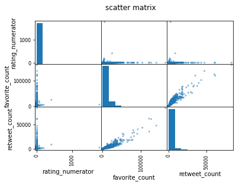

```python
pd.plotting.scatter_matrix(model_df);
plt.suptitle('scatter matrix');
```

### observations:

- From above we can clearly say, There doesn't exist's a great correlation between favorite count and rating numerator, its only 0.016.
- Also the corelation between rating_numerator and retweet_count is also pretty low 0.0188. #### so based on the low corelation value of 0.016 between rating numerator and favorite count we can't say that the tweets which having numerator ratings are more favorites or are more liked. #### similarly based on the low corelation value of 0.0188 between rating numerator and retweet count we can't say that the tweets which having numerator ratings are more likely retweeted.

#### - Interestingly corelation between favorite count and retweet count is pretty high 0.929, which indicates that tweets that are more favorites are also the tweets that are more retweeted.

### Now lets see some stats between features

```python
model_df.describe()
```

|  | tweet_id | rating_numerator | favorite_count | retweet_count |
| --- | --- | --- | --- | --- |
| count | 1.967000e+03 | 1967.000000 | 1967.000000 | 1967.000000 |
| mean | 7.359822e+17 | 12.223183 | 8707.332486 | 2642.418404 |
| std | 6.751247e+16 | 41.676313 | 12769.801532 | 4712.234607 |
| min | 6.660209e+17 | 0.000000 | 77.000000 | 11.000000 |
| 25% | 6.758494e+17 | 10.000000 | 1871.500000 | 589.000000 |
| 50% | 7.088109e+17 | 11.000000 | 3933.000000 | 1271.000000 |
| 75% | 7.880951e+17 | 12.000000 | 10857.000000 | 3015.000000 |
| max | 8.924206e+17 | 1776.000000 | 163129.000000 | 82968.000000 |

- From above we can 75% of rating_numerators lies below 12.0
- But the max value of rating numerator is 1776.0 which is very high. Lets see whether its a genuine case or outlier.

```python
model_df[model_df.rating_numerator == model_df.rating_numerator.max()]
```

|  | tweet_id | rating_numerator | favorite_count | retweet_count | name | dog_types | tweet_time |
| --- | --- | --- | --- | --- | --- | --- | --- |
| 1269 | 749981277374128128 | 1776 | 5344 | 2611 | Atticus | NaN | 2016-07-04 |

- So dog name Atticus with tweete id 749981277374128128 has received max rating numerator of 1776, lets see the dog pic and tweet and text

```python
print(max_num_df.text.iloc[0])
Image(url="https://pbs.twimg.com/media/CmgBZ7kWcAAlzFD.jpg")
```

```
This is Atticus. He's quite simply America af. 1776/10 https://t.co/GRXwMxLBkh
```

[figure not shown]

### Observations:

- On seeing the dog pic we can clearly say the Numerator rating is not an outlier.
- Indeed the dog(atticus) has received max numerical rating.
- Looks like this dog has history, and so many replies reveils that atticus is related to america's nation pride.
- The same thing, we can see in atticus pic, which is wearing US flag.

### Now lets read one part of the problem statement

Problem statemet about rating numerator and I quote below

" These ratings almost always have a denominator of 10. The numerators, though? Almost always greater than 10. 11/10, 12/10, 13/10, etc. Why? Because "they're good dogs Brent."

- So according to problem statement rating numerator almost always greater than 10.
- Lets see whether the rating numerator is always above 10, and if not which cases, its failing.
- So we can answer the following question based on the above problem statement ### [Q] Whether the problem statement about rating numerator is correct.

```python
model_df[model_df.rating_numerator < 10].rating_numerator.value_counts().sum()
```

```
412
```

- As we can see there are 412 dogs with less than 10 rating, this clearly says that our problem statement is wrong about the rating numerator, indeed rating numerator are less than 10 also, lets see why is this so.

```python
low_numer_df.rating_numerator.value_counts()
```

```
9    150
8     95
7     52
5     33
6     32
3     19
4     16
2      9
1      5
0      1
Name: rating_numerator, dtype: int64
```

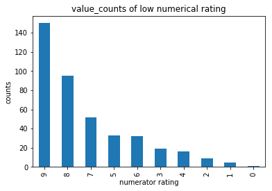

```python
low_numer_df.rating_numerator.value_counts().plot(kind = 'bar');
plt.xlabel("numerator rating")
plt.ylabel("counts")
plt.title("value_counts of low numerical rating");
```

- From above we can see that there is one dog with numerical rating zero.
- 5 dogs with numerical rating 1.
- 9 dogs with numerical rating 2
- 150 dogs with numerical rating 9. ### Observation:
- These clearly shows that our problem statement about numerical rating is wrong.
- Indeed There are dogs with numerical rating less than 10.

### Lets see some of the tweets with less than 3 numerical ratings and there images to get sense of the data and numerical rating

```python
final_df.query("rating_numerator < 3")[['tweet_id','text','jpg_url','rating_numerator','name']].sample(10)['text']
```

```
29     This is quite the dog. Gets really excited when not in water. Not very soft tho. Bad at fetch. Can't do tricks. 2/10 https://t.co/aMCTNWO94t
429    This is Henry. He's a shit dog. Short pointy ears. Leaves trail of pee. Not fluffy. Doesn't come when called. 2/10 https://t.co/Pu9RhfHDEQ
272    Scary dog here. Too many legs. Extra tail. Not soft, let alone fluffy. Won't bark. Moves sideways. Has weapon. 2/10 https://t.co/XOPXCSXiUT
573    This is Crystal. She's a shitty fireman. No sense of urgency. People could be dying Crystal. 2/10 just irresponsible https://t.co/rtMtjSl9pz
260    Flamboyant pup here. Probably poisonous. Won't eat kibble. Doesn't bark. Slow af. Petting doesn't look fun. 1/10 https://t.co/jxukeh2BeO
17     Not familiar with this breed. No tail (weird). Only 2 legs. Doesn't bark. Surprisingly quick. Shits eggs. 1/10 https://t.co/Asgdc6kuLX
45     Unfamiliar with this breed. Ears pointy af. Won't let go of seashell. Won't eat kibble. Not very fast. Bad dog 2/10 https://t.co/EIn5kElY1S
576    Exotic pup here. Tail long af. Throat looks swollen. Might breathe fire. Exceptionally unfluffy 2/10 would still pet https://t.co/a8SqCaSo2r
476    What kind of person sends in a picture without a dog in it? 1/10 just because that's a nice table https://t.co/RDXCfk8hK0
6      This is an odd dog. Hard on the outside but loving on the inside. Petting still fun. Doesn't play catch well. 2/10 https://t.co/v5A4vzSDdc
Name: text, dtype: object
```

```python
less_than_3_ratings = final_df.query("rating_numerator < 3")[['tweet_id','jpg_url','rating_numerator','p1','text']]
```

```python
less_than_3_ratings
```

|  | tweet_id | jpg_url | rating_numerator | p1 | text |
| --- | --- | --- | --- | --- | --- |
| 6 | 666051853826850816 | https://pbs.twimg.com/media/CT5KoJ1WoAAJash.jpg | 2 | box_turtle | This is an odd dog. Hard on the outside but loving on the inside. Petting still fun. Doesn't play catch well. 2/10 https://t.co/v5A4vzSDdc |
| 17 | 666104133288665088 | https://pbs.twimg.com/media/CT56LSZWoAAlJj2.jpg | 1 | hen | Not familiar with this breed. No tail (weird). Only 2 legs. Doesn't bark. Surprisingly quick. Shits eggs. 1/10 https://t.co/Asgdc6kuLX |
| 20 | 666287406224695296 | https://pbs.twimg.com/media/CT8g3BpUEAAuFjg.jpg | 1 | Maltese_dog | This is an Albanian 3 1/2 legged Episcopalian. Loves well-polished hardwood flooring. Penis on the collar. 9/10 https://t.co/d9NcXFKwLv |
| 29 | 666411507551481857 | https://pbs.twimg.com/media/CT-RugiWIAELEaq.jpg | 2 | coho | This is quite the dog. Gets really excited when not in water. Not very soft tho. Bad at fetch. Can't do tricks. 2/10 https://t.co/aMCTNWO94t |
| 45 | 666786068205871104 | https://pbs.twimg.com/media/CUDmZIkWcAAIPPe.jpg | 2 | snail | Unfamiliar with this breed. Ears pointy af. Won't let go of seashell. Won't eat kibble. Not very fast. Bad dog 2/10 https://t.co/EIn5kElY1S |
| 93 | 667549055577362432 | https://pbs.twimg.com/media/CUOcVCwWsAERUKY.jpg | 1 | electric_fan | Never seen dog like this. Breathes heavy. Tilts head in a pattern. No bark. Shitty at fetch. Not even cordless. 1/10 https://t.co/i9iSGNn3fx |
| 108 | 667878741721415682 | https://pbs.twimg.com/media/CUTILFiWcAE8Rle.jpg | 2 | seat_belt | This is Tedrick. He lives on the edge. Needs someone to hit the gas tho. Other than that he's a baller. 10&amp;2/10 https://t.co/LvP1TTYSCN |
| 117 | 668142349051129856 | https://pbs.twimg.com/media/CUW37BzWsAAlJlN.jpg | 2 | Angora | This lil pup is Oliver. Hops around. Has wings but doesn't fly (lame). Annoying chirp. Won't catch tennis balls 2/10 https://t.co/DnhUw0aBM2 |
| 260 | 670783437142401025 | https://pbs.twimg.com/media/CU8Z-OxXAAA-sd2.jpg | 1 | lacewing | Flamboyant pup here. Probably poisonous. Won't eat kibble. Doesn't bark. Slow af. Petting doesn't look fun. 1/10 https://t.co/jxukeh2BeO |
| 272 | 670826280409919488 | https://pbs.twimg.com/media/CU9A8ZuWsAAt_S1.jpg | 2 | scorpion | Scary dog here. Too many legs. Extra tail. Not soft, let alone fluffy. Won't bark. Moves sideways. Has weapon. 2/10 https://t.co/XOPXCSXiUT |
| 429 | 674265582246694913 | https://pbs.twimg.com/media/CVt49k_WsAAtNYC.jpg | 2 | slug | This is Henry. He's a shit dog. Short pointy ears. Leaves trail of pee. Not fluffy. Doesn't come when called. 2/10 https://t.co/Pu9RhfHDEQ |
| 476 | 675153376133427200 | https://pbs.twimg.com/media/CV6gaUUWEAAnETq.jpg | 1 | paper_towel | What kind of person sends in a picture without a dog in it? 1/10 just because that's a nice table https://t.co/RDXCfk8hK0 |
| 573 | 678424312106393600 | https://pbs.twimg.com/media/CWo_T8gW4AAgJNo.jpg | 2 | Maltese_dog | This is Crystal. She's a shitty fireman. No sense of urgency. People could be dying Crystal. 2/10 just irresponsible https://t.co/rtMtjSl9pz |
| 576 | 678675843183484930 | https://pbs.twimg.com/media/CWskEqnWUAAQZW_.jpg | 2 | maze | Exotic pup here. Tail long af. Throat looks swollen. Might breathe fire. Exceptionally unfluffy 2/10 would still pet https://t.co/a8SqCaSo2r |
| 1820 | 835152434251116546 | https://pbs.twimg.com/media/C5cOtWVWMAEjO5p.jpg | 0 | swing | When you're so blinded by your systematic plagiarism that you forget what day it is. 0/10 https://t.co/YbEJPkg4Ag |

```python
HTML(html_im)
```

|  | tweet_id | jpg_url | rating_numerator | p1 | text |
| --- | --- | --- | --- | --- | --- |
| 6 | 666051853826850816 |  | 2 | box_turtle | This is an odd dog. Hard on the outside but loving on the inside. Petting still fun. Doesn't play catch well. 2/10 https://t.co/v5A4vzSDdc |
| 17 | 666104133288665088 |  | 1 | hen | Not familiar with this breed. No tail (weird). Only 2 legs. Doesn't bark. Surprisingly quick. Shits eggs. 1/10 https://t.co/Asgdc6kuLX |
| 20 | 666287406224695296 |  | 1 | Maltese_dog | This is an Albanian 3 1/2 legged Episcopalian. Loves well-polished hardwood flooring. Penis on the collar. 9/10 https://t.co/d9NcXFKwLv |
| 29 | 666411507551481857 |  | 2 | coho | This is quite the dog. Gets really excited when not in water. Not very soft tho. Bad at fetch. Can't do tricks. 2/10 https://t.co/aMCTNWO94t |
| 45 | 666786068205871104 |  | 2 | snail | Unfamiliar with this breed. Ears pointy af. Won't let go of seashell. Won't eat kibble. Not very fast. Bad dog 2/10 https://t.co/EIn5kElY1S |
| 93 | 667549055577362432 |  | 1 | electric_fan | Never seen dog like this. Breathes heavy. Tilts head in a pattern. No bark. Shitty at fetch. Not even cordless. 1/10 https://t.co/i9iSGNn3fx |
| 108 | 667878741721415682 |  | 2 | seat_belt | This is Tedrick. He lives on the edge. Needs someone to hit the gas tho. Other than that he's a baller. 10&2/10 https://t.co/LvP1TTYSCN |
| 117 | 668142349051129856 |  | 2 | Angora | This lil pup is Oliver. Hops around. Has wings but doesn't fly (lame). Annoying chirp. Won't catch tennis balls 2/10 https://t.co/DnhUw0aBM2 |
| 260 | 670783437142401025 |  | 1 | lacewing | Flamboyant pup here. Probably poisonous. Won't eat kibble. Doesn't bark. Slow af. Petting doesn't look fun. 1/10 https://t.co/jxukeh2BeO |
| 272 | 670826280409919488 |  | 2 | scorpion | Scary dog here. Too many legs. Extra tail. Not soft, let alone fluffy. Won't bark. Moves sideways. Has weapon. 2/10 https://t.co/XOPXCSXiUT |
| 429 | 674265582246694913 |  | 2 | slug | This is Henry. He's a shit dog. Short pointy ears. Leaves trail of pee. Not fluffy. Doesn't come when called. 2/10 https://t.co/Pu9RhfHDEQ |
| 476 | 675153376133427200 |  | 1 | paper_towel | What kind of person sends in a picture without a dog in it? 1/10 just because that's a nice table https://t.co/RDXCfk8hK0 |
| 573 | 678424312106393600 |  | 2 | Maltese_dog | This is Crystal. She's a shitty fireman. No sense of urgency. People could be dying Crystal. 2/10 just irresponsible https://t.co/rtMtjSl9pz |
| 576 | 678675843183484930 |  | 2 | maze | Exotic pup here. Tail long af. Throat looks swollen. Might breathe fire. Exceptionally unfluffy 2/10 would still pet https://t.co/a8SqCaSo2r |
| 1820 | 835152434251116546 |  | 0 | swing | When you're so blinded by your systematic plagiarism that you forget what day it is. 0/10 https://t.co/YbEJPkg4Ag |

### Lets also see some of the tweets with 7 numerical rating

```python
HTML(html_im_7)
```

|  | tweet_id | jpg_url | rating_numerator | p1 | text |
| --- | --- | --- | --- | --- | --- |
| 1 | 666029285002620928 |  | 7 | redbone | This is a western brown Mitsubishi terrier. Upset about leaf. Actually 2 dogs here. 7/10 would walk the shit out of https://t.co/r7mOb2m0UI |
| 28 | 666407126856765440 |  | 7 | black-and-tan_coonhound | This is a southern Vesuvius bumblegruff. Can drive a truck (wow). Made friends with 5 other nifty dogs (neat). 7/10 https://t.co/LopTBkKa8h |
| 32 | 666428276349472768 |  | 7 | Pembroke | Here we have an Austrian Pulitzer. Collectors edition. Levitates (?). 7/10 would garden with https://t.co/NMQq6HIglK |
| 35 | 666437273139982337 |  | 7 | Chihuahua | Here we see a lone northeastern Cumberbatch. Half ladybug. Only builds with bricks. Very confident with body. 7/10 https://t.co/7LtjBS0GPK |
| 58 | 667090893657276420 |  | 7 | Chihuahua | This is Clybe. He is an Anemone Valdez. One ear works. Can look in 2 different directions at once. Tongue slip. 7/10 https://t.co/Ks0jZtdIrr |
| 75 | 667405339315146752 |  | 7 | Saint_Bernard | This is Biden. Biden just tripped... 7/10 https://t.co/3Fm9PwLju1 |
| 80 | 667455448082227200 |  | 7 | Tibetan_terrier | This is Reese and Twips. Reese protects Twips. Both think they're too good for seat belts. Simply reckless. 7/10s https://t.co/uLzRi1drVK |
| 82 | 667491009379606528 |  | 7 | borzoi | Two dogs in this one. Both are rare Jujitsu Pythagoreans. One slightly whiter than other. Long legs. 7/10 and 8/10 https://t.co/ITxxcc4v9y |
| 96 | 667724302356258817 |  | 7 | ibex | What a dog to start the day with. Very calm. Likes to chill by pond. Corkscrews sticking out of head. Obedient. 7/10 https://t.co/0nIxPTDWAZ |
| 119 | 668171859951755264 |  | 7 | Chihuahua | This is a Trans Siberian Kellogg named Alfonso. Huge ass eyeballs. Actually Dobby from Harry Potter. 7/10 https://t.co/XpseHBlAAb |
| 142 | 668614819948453888 |  | 7 | bustard | Here is a horned dog. Much grace. Can jump over moons (dam!). Paws not soft. Bad at barking. 7/10 can still pet tho https://t.co/2Su7gmsnZm |
| 155 | 668815180734689280 |  | 7 | redbone | This is a wild Toblerone from Papua New Guinea. Mouth always open. Addicted to hay. Acts blind. 7/10 handsome dog https://t.co/IGmVbz07tZ |
| 168 | 668988183816871936 |  | 7 | Arabian_camel | Honor to rate this dog. Lots of fur on him. Two massive tumors on back. Should get checked out. Very neat tho. 7/10 https://t.co/bMhs18elNF |
| 193 | 669571471778410496 |  | 7 | minivan | This is Keith. He's had 13 DUIs. 7/10 that's too many Keith https://t.co/fa7olwrF9Y |
| 244 | 670465786746662913 |  | 7 | axolotl | Silly dog here. Wearing bunny ears. Nice long tail. Unique paws. Not crazy soft but will do. Extremely agile. 7/10 https://t.co/2BnCLtJMxD |
| 258 | 670780561024270336 |  | 7 | Labrador_retriever | This is Traviss. He has no ears. Two rare dogs in background. I bet they all get along nicely. 7/10s I'd pet all https://t.co/Viu56hVhhP |
| 263 | 670792680469889025 |  | 7 | brown_bear | This is Antony. He's a Sheraton Tetrahedron. Skips awkwardly. Doesn't look when he crosses the road (reckless). 7/10 https://t.co/gTy4WMXu8l |
| 274 | 670833812859932673 |  | 7 | Pekinese | This is Jett. He is unimpressed by flower. 7/10 https://t.co/459qWNnV3F |
| 297 | 671390180817915904 |  | 7 | zebra | Striped dog here. Having fun playing on back. Sturdy paws. Looks like an organized Dalmatian. 7/10 would still pet https://t.co/U1mSS3Ykez |
| 328 | 672068090318987265 |  | 7 | pug | Say hello to Gizmo. He's upset because he's not sure if he's really big or the shopping cart is really small. 7/10 https://t.co/XkMtCGhr4a |
| 338 | 672239279297454080 |  | 7 | pug | This is Ridley. He doesn't know how to couch. 7/10 https://t.co/UHJE0UgMf7 |
| 352 | 672538107540070400 |  | 7 | Siamese_cat | Meet Darby. He's a Fiscal Tutankhamen Waxbeard. Really likes steak. 7/10 https://t.co/rSndxTL0Ap |
| 369 | 672970152493887488 |  | 7 | leaf_beetle | This is Chet. He's having a hard time. Really struggling. 7/10 hang in there pupper https://t.co/eb4ta0xtnd |
| 385 | 673345638550134785 |  | 7 | hamster | This is Gerald. He's a fluffy lil yellow pup. Always looks like his favorite team just lost on a hail mary. 7/10 https://t.co/GpSkpN8kXS |
| 391 | 673576835670777856 |  | 7 | teddy | Sun burnt dog here. Quite large. Wants to promote peace. Looks unemployed. Ears for days. 7/10 would pet profusely https://t.co/WlKiN3ll0w |
| 394 | 673612854080196609 |  | 7 | Newfoundland | This is Jeffri. He's a speckled ice pupper. Very lazy. Enjoys the occasional swim. Rather majestic really. 7/10 https://t.co/0iyItbtkr8 |
| 473 | 675146535592706048 |  | 7 | dingo | This is Coops. He's yelling at the carpet. Not very productive Coops. 7/10 https://t.co/Uz52oYnHzF |
| 582 | 678798276842360832 |  | 7 | Airedale | This is Linda. She fucking hates trees. 7/10 https://t.co/blaY85FIxR |
| 595 | 679511351870550016 |  | 7 | Chihuahua | Say hello to William. He makes fun of others because he's terrified of his own deep-seated insecurities. 7/10 https://t.co/bwuV6FlRxr |
| 597 | 679530280114372609 |  | 7 | dalmatian | Guys this really needs to stop. We've been over this way too many times. This is a giraffe. We only rate dogs.. 7/10 https://t.co/yavgkHYPOC |
| 604 | 679854723806179328 |  | 7 | llama | This is Bruce. He's a rare pup. Covered in Frosted Flakes. Nifty gold teeth. Overall good dog. 7/10 would pet firmly https://t.co/RtxxACzZ8A |
| 646 | 681679526984871937 |  | 7 | birdhouse | Can you spot Toby the guilty pupper? 7/10 would be higher but he made quite the mess shredding his stuffed pals https://t.co/3uCcDEJLXs |
| 659 | 682406705142087680 |  | 7 | wombat | This is Patrick. He's a bigass pupper. 7/10 https://t.co/J9DXBFoAQe |
| 666 | 682962037429899265 |  | 7 | dingo | This is Darrel. He just robbed a 7/11 and is in a high speed police chase. Was just spotted by the helicopter 10/10 https://t.co/7EsP8LmSp5 |
| 715 | 685641971164143616 |  | 7 | Lakeland_terrier | This is Otis. He just passed a cop while going 61 in a 45. Very nervous pupper. 7/10 https://t.co/jJS8qQeuNO |
| 739 | 687312378585812992 |  | 7 | seat_belt | "You got any games on your phone" 7/10 for invasive brown Dalmatian pupper https://t.co/yzGR9xjE9Q |
| 744 | 687494652870668288 |  | 7 | Rottweiler | This is Marq. He stole this car. 7/10 wtf Marq? https://t.co/MHScqo5l8c |
| 760 | 688894073864884227 |  | 7 | hog | This is Hamrick. He's covered in corn flakes. Silly pupper. Looks congested. 7/10 considerably petable https://t.co/ROPZcAMQKI |
| 810 | 692417313023332352 |  | 7 | bison | Meet Herschel. He's slightly bigger than ur average pupper. Looks lonely. Could probably ride 7/10 would totally pet https://t.co/VGaIMktX10 |
| 831 | 693647888581312512 |  | 7 | washbasin | What kind of person sends in a pic without a dog in it? So churlish. Neat rug tho 7/10 https://t.co/LSTAwTdTaw |
| 852 | 696405997980676096 |  | 7 | borzoi | This is Berb. He just found out that they have made 31 Kidz Bop CD's. Downright terrifying. 7/10 hang in there Berb https://t.co/CIFLjiTFwZ |
| 880 | 698703483621523456 |  | 7 | Brittany_spaniel | This is Rusty. He has no respect for POULTRY products. Unbelievable af. 7/10 would still pet https://t.co/hEH19t1eFp |
| 910 | 700796979434098688 |  | 7 | tailed_frog | This is Daniel. He's a neat pup. Exotic af. Custom paws. Leaps unannounced. Would totally pet. 7/10 daaamn Daniel https://t.co/5XaR0kj8cr |
| 947 | 704819833553219584 |  | 7 | guinea_pig | This is Chesterson. He's a Bolivian Scoop Dog. Incredibly portable. Can't bark for shit tho. 7/10 would still pet https://t.co/EatAd8JhyW |
| 963 | 706166467411222528 |  | 7 | Samoyed | This is Dexter. He's a shy pup. Doesn't bark much. Dreadful fetcher. Has rare sun allergy. 7/10 still petable https://t.co/sA7P3JSqiv |
| 985 | 707693576495472641 |  | 7 | bathtub | This is Jiminus. He's in a tub for some reason. What a jokester. Smh 7/10 churlish af https://t.co/84L4ED9Tpi |
| 1039 | 712092745624633345 |  | 7 | triceratops | This is Steven. He's inverted af. Also very helpful. Scans anything you want for free. Takes him a while tho. 7/10 https://t.co/tA0ZiQ7JcG |
| 1216 | 743595368194129920 |  | 7 | hippopotamus | This is Harold. He looks slippery af. Probably difficult to hug. Would still try tho. 7/10 great with kids I bet https://t.co/EVuqdEO66N |
| 1229 | 745712589599014916 |  | 7 | seat_belt | This is Percy. He fell asleep at the wheel. Irresponsible af. 7/10 absolute menace on the roadway https://t.co/QHbvtvaw8E |
| 1252 | 748307329658011649 |  | 7 | paddle | This sherk must've leapt out of the water and into the canoe, trapping the human. Won't even help paddle smh. 7/10 https://t.co/KubWEqOIgO |
| 1341 | 759099523532779520 |  | 7 | Shetland_sheepdog | Meet Toby. He has a drinking problem. Inflatable marijuana plant in the back is also not a good look. 7/10 cmon Toby https://t.co/Cim4DSj6Oi |
| 1411 | 771014301343748096 |  | 7 | meerkat | Another pic without a dog in it? What am I supposed to do? Rate the carpet? Fine I will. 7/10 looks adequately comfy https://t.co/OJZQ6I4gGd |

### Observations:

1. As we can see out of 15 tweets which has less than 3 ratings, 13 images are not even dogs.
2. So we can say most of the tweets which got less than 10 rating either doesnot belong to dog, or the dog has some problems like blind, deaf, some even are cars, sunflowers etc.
3. We can't comment that every tweet is like that but most of tweets are like that.

## Summary of whole analysis:

1. Gathered data from three sources, tweets information from twitter api, image data from image_predictions.tsv and text info form twitter-archive-enhanced.csv.
2. Assess the dataset and found data quality and and data structure issues.
3. Cleaned all the data quality and strutural issues in data cleaning section.
4. After cleaning the dataset analyzed the dataset and found out the following observations.
5. There doesn't exist's a great correlation between favorite count and rating numerator only 0.016.
6. Also the corelation between rating_numerator and retweet_count is also pretty low 0.0188.
7. corelation between favorite count and retweet count is pretty high 0.929.
8. Indeed the dog(atticus) has received max numerical rating of 1776.
9. Looks like this dog has history, and so many replies reveils that atticus is related to america's nation pride. The same thing, we can see in atticus pic, which is wearing US flag.
10. according to problem statement rating numerator almost always greater than 10, but according to our observations there are enought dogs with less than 10 numerator ratings.
11. we can see out of 15 tweets which has less than 3 ratings, 13 images are not even dogs.
12. So we can say most of the tweets which got less than 10 rating either doesnot belong to dog, or the dog has some problems like blind, deaf, some even are cars, sunflowers etc.
13. We can't comment that every tweet with less than 10 are not dogs but we can say most of them. and further analysis is required to get more info.